# R Notebook

### 1.

```r
seeds <- read.table("http://www-eio.upc.es/%7Ejan/Data/MVA/seedsdataset.dat", col.names = c("Area", "Perimeter", "Compacidad", "longitud", "ancho", "coef.asimetria", "long.ranura", "variedad"))
head(seeds)
```

|  | Area | Perimeter | Compacidad | longitud | ancho | coef.asimetria | long.ranura | variedad |
| --- | --- | --- | --- | --- | --- | --- | --- | --- |
| 1 | 15.26 | 14.84 | 0.8710 | 5.763 | 3.312 | 2.221 | 5.220 | 1 |
| 2 | 14.88 | 14.57 | 0.8811 | 5.554 | 3.333 | 1.018 | 4.956 | 1 |
| 3 | 14.29 | 14.09 | 0.9050 | 5.291 | 3.337 | 2.699 | 4.825 | 1 |
| 4 | 13.84 | 13.94 | 0.8955 | 5.324 | 3.379 | 2.259 | 4.805 | 1 |
| 5 | 16.14 | 14.99 | 0.9034 | 5.658 | 3.562 | 1.355 | 5.175 | 1 |
| 6 | 14.38 | 14.21 | 0.8951 | 5.386 | 3.312 | 2.462 | 4.956 | 1 |

### 2.

```r
variedad <- seeds[,8]
seeds <- seeds[,-8]
nums <- row.names(seeds)
```

### 3. Las dos únicas anomalías son que el coeficiente de asimetría tiene algunos valores muy altos y que la longitud de la ranura no tiene una distribución simétrica. Aún así, nada extremo.

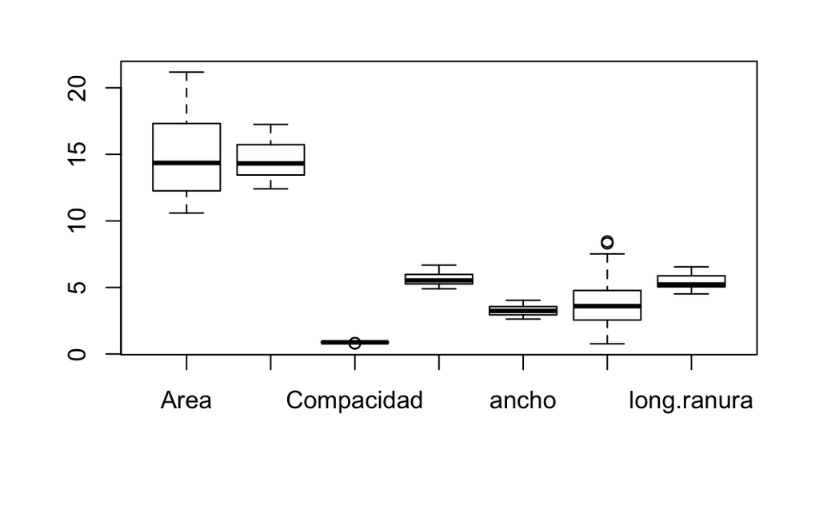

```r
boxplot(seeds)
```

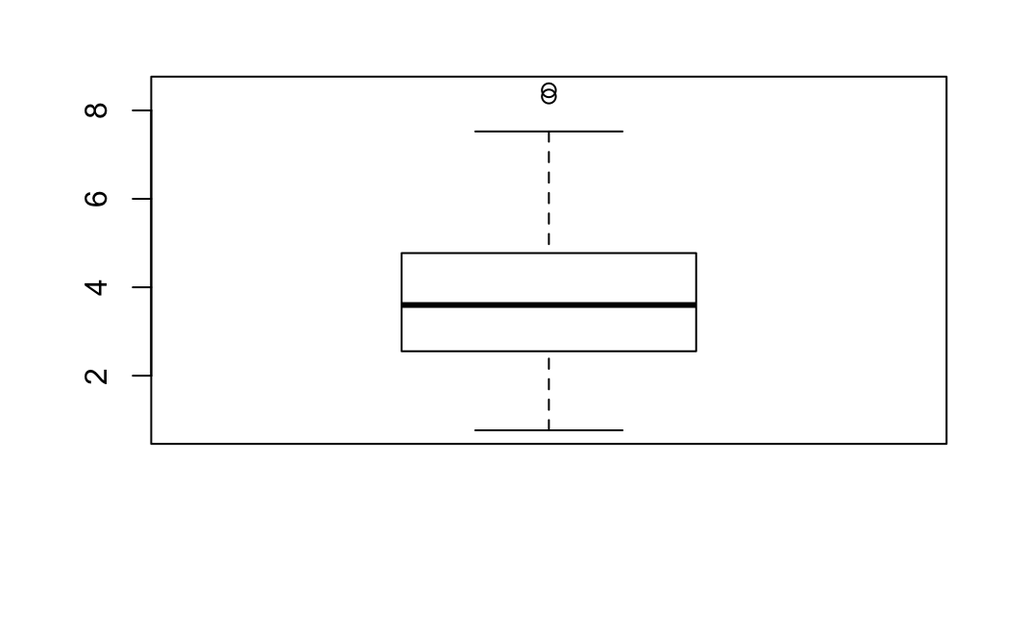

```r
boxplot(seeds$coef.asimetria)
```

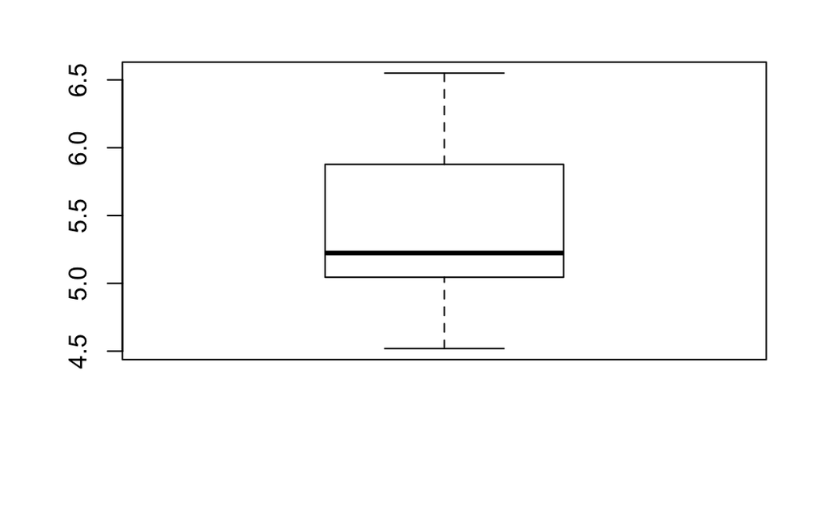

```r
boxplot(seeds$long.ranura)
```

### 4. Al haber relaciones no lineales entre las variables salen formas diversas. El coeficiente de asimetría parece no tener correlación con ninguna variable. Y en algunos plots parecen diferenciarse al menos dos grupos. Por lo demás no parece que haya anomalías destacables.

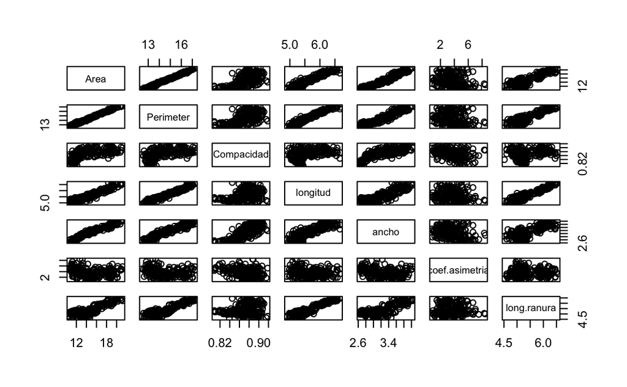

```r
pairs(seeds)
```

### 5.

```r
seeds <- scale(seeds)
dist.st <- dist(seeds)
as.matrix(dist.st)[1:5,1:5]
```

```
         1        2         3         4        5
1 0.000000 1.181864 2.0970435 1.8748257 1.679029
2 1.181864 0.000000 1.6949066 1.3385798 1.361268
3 2.097044 1.694907 0.0000000 0.5513196 1.797465
4 1.874826 1.338580 0.5513196 0.0000000 1.764733
5 1.679029 1.361268 1.7974648 1.7647326 0.000000
```

### 6. Si a partir de este dendograma tuvieramos que decir que hay tres variedades concluiriamos que dos de ellas solo aparecen en tres semillas. Este dendograma no separa demasiado y junta muchas semillas en un mismo grupo, por lo que no queda nada claro que haya tres variedades a partir de este dendograma.

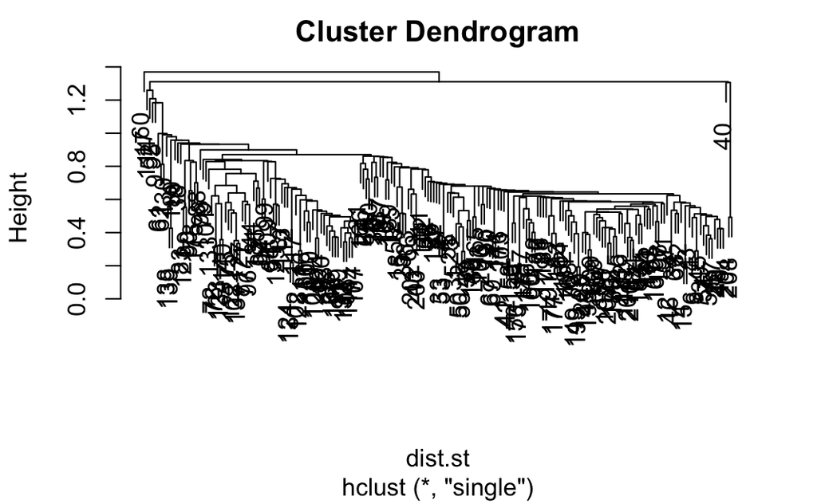

```r
out.s <- hclust(dist.st, method = "single")
plot(out.s)
```

### 7.

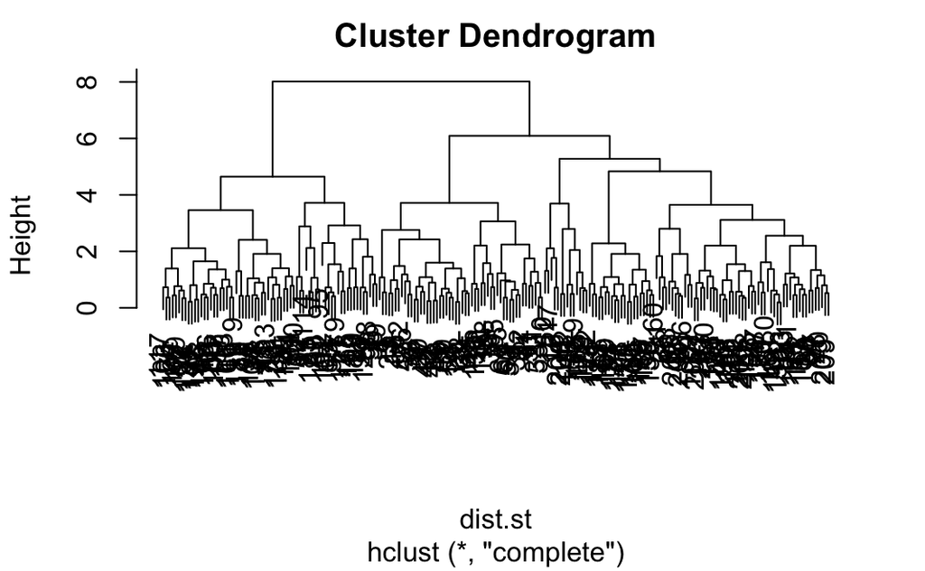

```r
out.c <- hclust(dist.st, method = "complete")
plot(out.c)
```

### 8. Basta cortar por un número cercano a 6, por ejemplo, 5,8. Vemos que de esta forma se identifican correctamente cluster y variedad en el 87% de las veces.

```r
groups.3 <- cutree(out.c, h = 5.8)
(cross.table <- table(groups.3, variedad))
```

```
        variedad
groups.3  1  2  3
       1 48  4  0
       2  2 66  0
       3 20  0 70
```

```r
sum(diag(cross.table))/sum(cross.table)
```

```
[1] 0.8761905
```

### 9. Se observa que la variedad “Kama” y “Canadian” se agrupan en un cluster y la variedad “Rosa” en otro con tan solo 7 semillas de “Kama” en el cluster 2 y 2 de “Rosa” en el cluster 1.

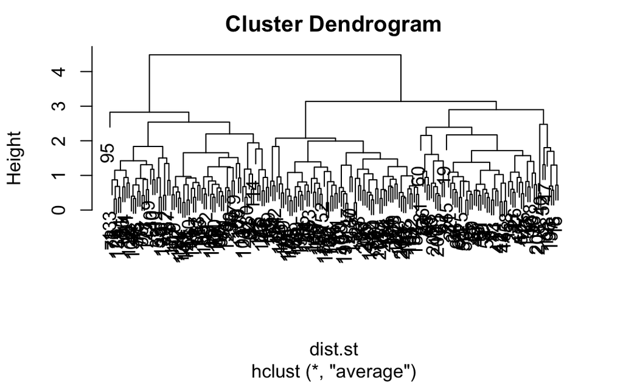

```r
out.a <- hclust(dist.st, method = "average")
plot(out.a)
```

```r
groups.2 <- cutree(out.a, k = 2)
(cross.table.2 <- table(groups.2, variedad))
```

```
        variedad
groups.2  1  2  3
       1 63  2 70
       2  7 68  0
```

### 10. Ahora la clasificación acierta en un 92% de las veces.

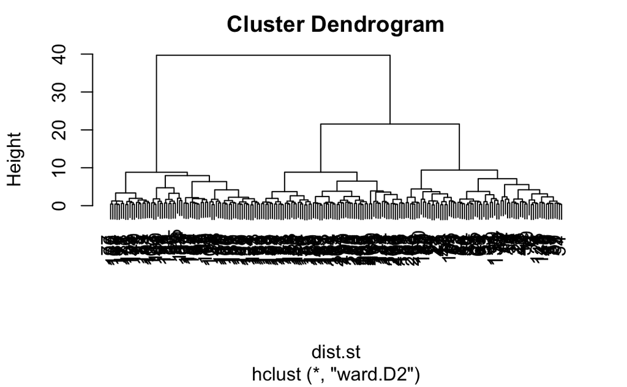

```r
out.w <- hclust(dist.st, method = "ward.D2")
plot(out.w)
```

```r
groups.3.ward <- cutree(out.w, k = 3)
(cross.table.ward <- table(groups.3.ward, variedad))
```

```
             variedad
groups.3.ward  1  2  3
            1 64  4  5
            2  4 66  0
            3  2  0 65
```

```r
sum(diag(cross.table.ward))/sum(cross.table.ward)
```

```
[1] 0.9285714
```

### 11. En primer lugar asocia el segundo grupo al tercero y el tercero al segundo. Obviando ese detalle acierta en un 92% de las veces, exactamente igual que con el método de Ward.

```r
set.seed(123)
(km <- kmeans(seeds, 3))
```

```
K-means clustering with 3 clusters of sizes 75, 66, 69

Cluster means:
        Area  Perimeter Compacidad   longitud       ancho
1 -0.2092509 -0.2443817  0.4209483 -0.3400265 -0.05324506
2 -1.0414310 -1.0111329 -1.0339614 -0.8859528 -1.11844610
3  1.2235980  1.2328029  0.5314541  1.2170272  1.12769307
  coef.asimetria long.ranura
1    -0.65890742  -0.6627691
2     0.79756054  -0.5820606
3    -0.04668027   1.2771548

Clustering vector:
  [1] 1 1 1 1 1 1 1 1 3 1 1 1 1 1 1 1 1 1 1 2 1 1 1 1 1 1 1 1 1 1 1 1 1
 [34] 1 1 1 1 3 1 1 1 1 1 1 1 1 1 1 1 1 1 1 1 1 1 1 1 1 1 1 2 1 1 1 1 1
 [67] 1 1 1 2 3 3 3 3 3 3 3 3 3 3 3 3 3 3 3 3 3 3 3 3 3 3 3 3 3 3 3 3 3
[100] 3 3 3 3 3 3 3 3 3 3 3 3 3 3 3 3 3 3 3 3 3 3 3 3 3 1 3 3 3 3 3 3 3
[133] 3 3 3 1 3 3 1 3 2 2 2 2 2 2 2 2 2 2 2 2 2 2 2 2 2 2 2 2 2 2 2 2 2
[166] 1 2 2 2 2 2 2 2 2 2 2 2 2 2 1 2 2 2 2 2 2 2 2 2 2 2 2 2 2 2 1 2 1
[199] 2 1 2 1 2 2 2 1 2 2 2 2

Within cluster sum of squares by cluster:
[1] 160.7960 118.2489 149.8787
 (between_SS / total_SS =  70.7 %)

Available components:

[1] "cluster"      "centers"      "totss"        "withinss"
[5] "tot.withinss" "betweenss"    "size"         "iter"
[9] "ifault"
```

```r
km$cluster[km$cluster==2] <- 4
km$cluster[km$cluster==3] <- 2
km$cluster[km$cluster==4] <- 3
(cross.table.km <- table(km$cluster, variedad))
```

```
   variedad
     1  2  3
  1 65  3  7
  2  2 67  0
  3  3  0 63
```

```r
sum(diag(cross.table.km))/sum(cross.table.km)
```

```
[1] 0.9285714
```

### 12. Según el criterio de Calinski-Harabasz la cantidad óptima de grupos es 2.

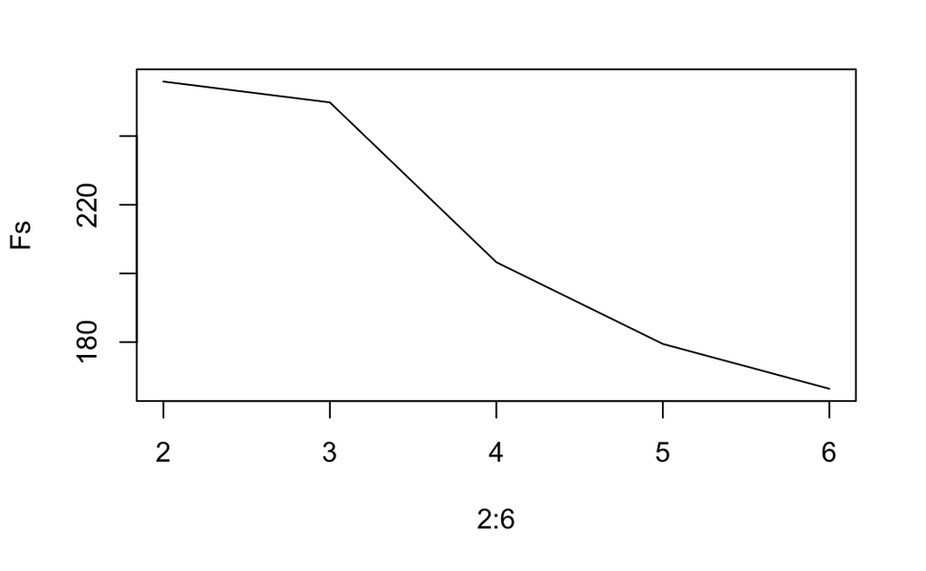

```r
library(clusterSim)
Fs <- c()
for (k in 2:6) {
  aux.km <- kmeans(seeds, k)
  Fs <- c(Fs, index.G1(seeds, aux.km$cluster))
}
plot(2:6, Fs, type="l")
```

### 13. Se equivoca en el 10% de los casos, peor que los otros criterios.

```r
library(mclust)
model <- Mclust(seeds, G=3)
```

```
fitting ...
```

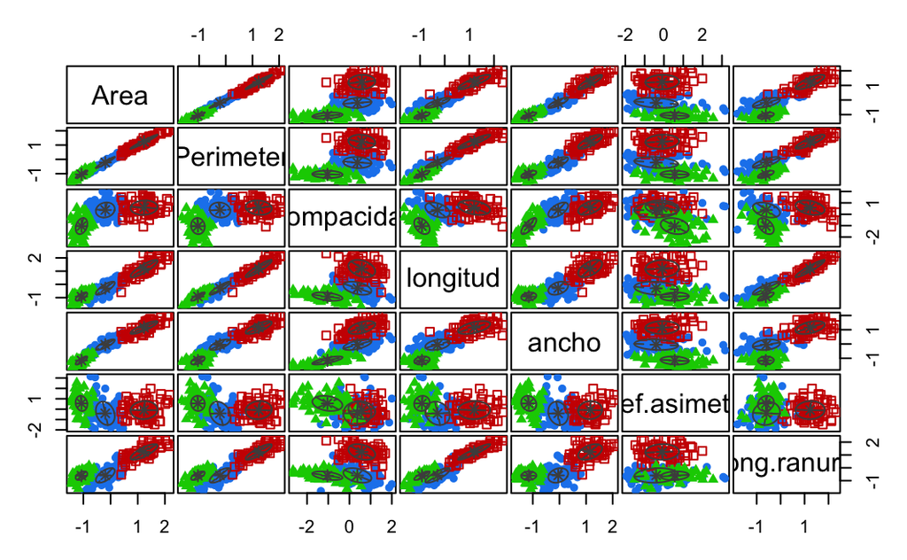

```r
plot(model, what="classification")
```

```r
(cross.table.mix <- table(model$classification, variedad))
```

```
   variedad
     1  2  3
  1 62  5  9
  2  4 65  0
  3  4  0 61
```

```r
sum(diag(cross.table.mix))/sum(cross.table.mix)
```

```
[1] 0.8952381
```

```r
1-sum(diag(cross.table.mix))/sum(cross.table.mix)
```

```
[1] 0.1047619
```

```r
summary(model, parameters=T)
```

```
----------------------------------------------------
Gaussian finite mixture model fitted by EM algorithm
----------------------------------------------------

Mclust VEV (ellipsoidal, equal shape) model with 3 components:
```

|  | log-likelihood | n | df | BIC | ICL |
| --- | --- | --- | --- | --- | --- |
|  | 286.9906 | 210 | 95 | 66.00606 | 61.46508 |

```
Clustering table:
 1  2  3
76 69 65

Mixing probabilities:
        1         2         3
0.3562048 0.3292496 0.3145456

Means:
                      [,1]        [,2]       [,3]
Area           -0.19388011  1.23212558 -1.0701654
Perimeter      -0.21719381  1.23362086 -1.0453292
Compacidad      0.37566701  0.58447221 -1.0372158
longitud       -0.28982784  1.19502462 -0.9226748
ancho          -0.04735981  1.15211284 -1.1523382
coef.asimetria -0.40489976 -0.09166457  0.5544754
long.ranura    -0.59511224  1.23316534 -0.6168814

Variances:
[,,1]
                      Area   Perimeter  Compacidad    longitud
Area            0.12144562  0.13078091  0.03352095  0.13767042
Perimeter       0.13078091  0.15012789 -0.02687849  0.17449489
Compacidad      0.03352095 -0.02687849  0.43975361 -0.13931557
longitud        0.13767042  0.17449489 -0.13931557  0.24703915
ancho           0.10652682  0.09716406  0.14759125  0.06790451
coef.asimetria -0.09776403 -0.10992237  0.01013208 -0.09616981
long.ranura     0.12503361  0.16126201 -0.14368876  0.23102359
                     ancho coef.asimetria long.ranura
Area            0.10652682    -0.09776403  0.12503361
Perimeter       0.09716406    -0.10992237  0.16126201
Compacidad      0.14759125     0.01013208 -0.14368876
longitud        0.06790451    -0.09616981  0.23102359
ancho           0.13887717    -0.07100653  0.05333320
coef.asimetria -0.07100653     1.27456013  0.07884898
long.ranura     0.05333320     0.07884898  0.32444234
[,,2]
                     Area   Perimeter  Compacidad    longitud
Area           0.24571334  0.23736464  0.02389975  0.27730519
Perimeter      0.23736464  0.23996778 -0.04174738  0.29483435
```

[output cut: 15 more lines]

```
Area            0.04666010  0.051622296  0.04616061  0.04661951
Perimeter       0.05162230  0.066179236 -0.01316380  0.07052388
Compacidad      0.04616061 -0.013163802  0.50320005 -0.08958416
longitud        0.04661951  0.070523880 -0.08958416  0.09908369
ancho           0.05014025  0.041135870  0.15095889  0.01953689
coef.asimetria -0.02140026 -0.009335883 -0.12646897  0.02140885
long.ranura     0.03384423  0.056991776 -0.10628898  0.08504606
                      ancho coef.asimetria  long.ranura
Area            0.050140248   -0.021400263  0.033844229
Perimeter       0.041135870   -0.009335883  0.056991776
Compacidad      0.150958890   -0.126468967 -0.106288978
longitud        0.019536886    0.021408846  0.085046062
ancho           0.081261244   -0.030061529  0.005673097
coef.asimetria -0.030061529    0.532393161  0.038368707
long.ranura     0.005673097    0.038368707  0.112333524
```

```r
model$classification
```

```
  [1] 1 1 1 1 1 1 1 1 2 2 1 1 1 1 1 1 1 1 1 1 1 1 1 3 1 1 1 1 1 1 1 1 1
 [34] 1 1 2 1 2 1 1 1 1 1 1 1 1 1 1 1 1 1 1 1 1 1 1 1 1 1 1 3 3 1 1 1 1
 [67] 1 1 1 3 2 2 2 2 2 2 2 2 2 2 2 2 2 2 2 2 2 2 2 2 2 2 2 2 2 2 2 2 2
[100] 2 2 2 2 2 2 2 2 2 2 2 2 2 2 2 2 2 2 2 2 2 2 2 2 2 2 2 2 2 2 2 2 2
[133] 1 2 1 1 2 1 1 2 3 1 1 3 3 3 3 3 3 3 3 3 3 3 3 3 3 3 3 3 3 3 3 3 3
[166] 3 3 3 3 3 3 3 3 3 3 3 3 3 3 3 3 3 3 3 3 3 3 3 3 3 3 3 3 3 3 1 1 1
[199] 3 1 3 1 3 1 3 3 3 1 3 3
```

### 14. En total, los tres métodos clasifican mal 6 semillas simultáneamente.

```r
(err.ward <- nums[groups.3.ward != variedad])
```

```
 [1] "10"  "20"  "36"  "38"  "44"  "70"  "125" "136" "138" "139" "147"
[12] "166" "180" "200" "202"
```

```r
(err.km <- nums[km$cluster != variedad])
```

```
 [1] "9"   "20"  "38"  "61"  "70"  "125" "136" "139" "166" "180" "196"
[12] "198" "200" "202" "206"
```

```r
(err.km <- err.km[err.km %in% err.ward])
```

```
 [1] "20"  "38"  "70"  "125" "136" "139" "166" "180" "200" "202"
```

```r
(err.gauss <- nums[model$classification != variedad])
```

```
 [1] "9"   "10"  "24"  "36"  "38"  "61"  "62"  "70"  "133" "135" "136"
[12] "138" "139" "142" "143" "196" "197" "198" "200" "202" "204" "208"
```

```r
(err <- err.gauss[err.gauss %in% err.km])
```

```
[1] "38"  "70"  "136" "139" "200" "202"
```

```r
(err <- sort(as.numeric(err[!duplicated(err)])))
```

```
[1]  38  70 136 139 200 202
```

```r
length(err)
```

```
[1] 6
```

```r
plot(acp$scores[,1], acp$scores[,2], col=cols, asp = 1)
```

[output not shown]

[output not shown]

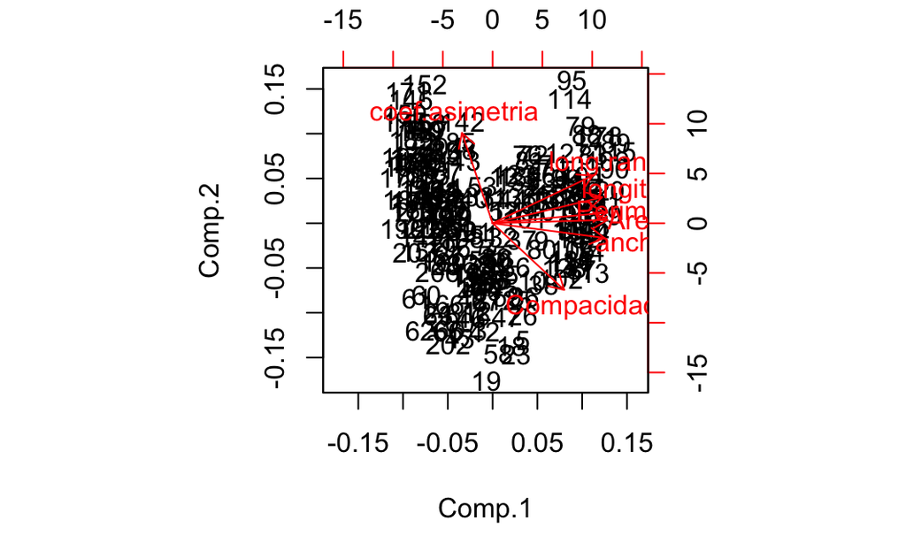

```r
biplot(acp)
```